# Image Retrieval

Author

Steven Ndung’u et al.

Published

May 27, 2024

## Model Evaluation COSFIRE Filters Approach

The results in this presentation are from two experimental designs:

**Experiment 1 Results**

We obtain the 26 statistically significant sets of hyperparameters from the classification paper along with their respective training, validation, and test descriptors. Based on these descriptors, we perform image hashing for each set of descriptors using a selected set of MLP hyperparameters (for the grid search).

**Important**

Importantly, each row represents a unique combination of MLP hyperparameters, and every column represents the results yielded by each of the 26 statistically significant sets of descriptors.

NB: The code used is [GitHub](https://GitHub.com/stevenndungu/deep_hashing/blob/main/validation_script_17052024.py)

[figure not shown]

#### Validation Data mAP Results Preview:

Here is the [Google Sheet - Validation Data](https://docs.google.com/spreadsheets/d/1qGltcEiCyVEVmhOki_eRrl1zyGGglFUF9F2XTVoW7jA/edit?usp=sharing) of the data

|  | input_size | output_size | learning_rate | batch_size | alpha | margin | mAP_valid | mAP_valid_2 | mAP_valid_3 | mAP_valid_4 | mAP_valid_5 | mAP_valid_6 | mAP_valid_7 | mAP_valid_8 | mAP_valid_9 | mAP_valid_10 | mAP_valid_11 | mAP_valid_12 | mAP_valid_13 | mAP_valid_14 | mAP_valid_15 | mAP_valid_16 | mAP_valid_17 | mAP_valid_18 | mAP_valid_19 | mAP_valid_20 | mAP_valid_21 | mAP_valid_22 | mAP_valid_23 | … |
| --- | --- | --- | --- | --- | --- | --- | --- | --- | --- | --- | --- | --- | --- | --- | --- | --- | --- | --- | --- | --- | --- | --- | --- | --- | --- | --- | --- | --- | --- | --- |
| 23 | 372 | 36 | 0.1000 | 64 | 0.00001 | 36 | 48.42 | 47.09 | 52.34 | 50.90 | 52.84 | 35.94 | 47.87 | 49.73 | 50.89 | 47.15 | 29.92 | 54.00 | 59.70 | 57.53 | 53.87 | 53.14 | 50.20 | 53.89 | 34.24 | 41.80 | 34.19 | 75.39 | 56.85 | … |
| 20 | 372 | 36 | 0.1000 | 64 | 0.00001 | 24 | 48.12 | 46.19 | 48.55 | 46.42 | 49.89 | 45.66 | 48.03 | 47.43 | 36.75 | 52.53 | 27.03 | 54.19 | 63.24 | 62.51 | 57.21 | 58.73 | 58.01 | 58.93 | 45.01 | 35.31 | 39.50 | 74.51 | 49.52 | … |
| 10 | 372 | 36 | 0.1000 | 32 | 0.00010 | 24 | 46.71 | 46.94 | 45.53 | 55.10 | 47.47 | 36.15 | 46.23 | 47.15 | 40.56 | 48.09 | 47.71 | 47.65 | 53.23 | 53.84 | 50.18 | 64.25 | 67.04 | 52.95 | 42.41 | 34.89 | 42.85 | 73.90 | 43.91 | … |
| 12 | 372 | 36 | 0.1000 | 16 | 0.00010 | 36 | 50.51 | 47.87 | 47.71 | 50.77 | 46.72 | 33.93 | 45.88 | 49.62 | 45.32 | 46.62 | 53.10 | 56.47 | 57.61 | 51.29 | 52.50 | 58.07 | 53.63 | 58.60 | 29.82 | 38.79 | 45.66 | 72.76 | 46.26 | … |
| 22 | 372 | 36 | 0.1000 | 32 | 0.00001 | 36 | 45.39 | 47.08 | 43.04 | 52.30 | 43.68 | 31.67 | 38.07 | 49.04 | 39.64 | 44.59 | 47.95 | 54.08 | 53.88 | 53.01 | 49.02 | 53.85 | 49.06 | 58.11 | 34.04 | 46.01 | 60.14 | 72.54 | 44.85 | … |
| 2 | 372 | 36 | 0.1000 | 64 | 0.00100 | 24 | 53.47 | 47.54 | 47.68 | 45.01 | 44.22 | 30.30 | 37.41 | 45.52 | 46.46 | 46.49 | 32.77 | 50.85 | 61.31 | 67.88 | 50.68 | 53.15 | 46.79 | 50.91 | 31.26 | 38.67 | 55.01 | 72.24 | 45.45 | … |
| 37 | 372 | 36 | 0.0100 | 32 | 0.00010 | 24 | 38.52 | 49.95 | 51.29 | 55.61 | 37.88 | 20.10 | 20.60 | 24.18 | 22.65 | 20.10 | 20.85 | 43.58 | 49.50 | 54.94 | 49.30 | 52.52 | 52.38 | 54.78 | 35.77 | 26.74 | 36.45 | 71.62 | 37.41 | … |
| 0 | 372 | 36 | 0.1000 | 16 | 0.00100 | 24 | 46.45 | 50.77 | 49.07 | 44.34 | 47.71 | 44.07 | 44.04 | 46.31 | 44.56 | 45.94 | 41.29 | 48.03 | 45.22 | 56.83 | 61.66 | 53.42 | 50.96 | 57.15 | 30.14 | 44.67 | 52.20 | 71.07 | 48.37 | … |
| 53 | 372 | 36 | 0.0100 | 64 | 0.00001 | 48 | 46.02 | 46.04 | 41.32 | 39.82 | 41.11 | 24.37 | 49.79 | 31.06 | 22.50 | 29.93 | 30.66 | 61.97 | 61.16 | 65.02 | 72.40 | 58.26 | 68.49 | 60.40 | 60.17 | 62.29 | 49.14 | 70.64 | 43.63 | … |
| 11 | 372 | 36 | 0.1000 | 64 | 0.00010 | 24 | 50.12 | 47.73 | 48.01 | 48.79 | 45.08 | 44.92 | 30.10 | 46.51 | 44.82 | 48.27 | 46.31 | 56.61 | 58.24 | 56.23 | 46.05 | 53.37 | 54.22 | 56.95 | 26.29 | 41.76 | 56.12 | 69.88 | 48.69 | … |
| 21 | 372 | 36 | 0.1000 | 16 | 0.00001 | 36 | 48.28 | 47.75 | 48.12 | 48.82 | 45.10 | 34.64 | 45.94 | 46.27 | 45.15 | 46.17 | 49.53 | 55.18 | 61.19 | 57.41 | 52.13 | 45.05 | 54.31 | 58.75 | 46.58 | 28.31 | 45.60 | 69.50 | 47.37 | … |
| 35 | 372 | 36 | 0.0100 | 64 | 0.00100 | 48 | 53.50 | 40.28 | 60.56 | 39.73 | 40.89 | 27.54 | 50.51 | 37.65 | 58.33 | 39.29 | 39.55 | 55.57 | 62.16 | 57.93 | 59.19 | 63.48 | 70.93 | 65.91 | 21.08 | 44.83 | 53.24 | 68.62 | 45.74 | … |
| 51 | 372 | 36 | 0.0100 | 16 | 0.00001 | 48 | 44.59 | 45.20 | 42.44 | 40.89 | 36.94 | 26.40 | 41.67 | 41.59 | 37.89 | 21.49 | 31.53 | 29.28 | 62.19 | 46.98 | 49.80 | 38.24 | 42.71 | 37.65 | 21.24 | 21.18 | 56.39 | 68.60 | 25.92 | … |
| 1 | 372 | 36 | 0.1000 | 32 | 0.00100 | 24 | 47.76 | 49.32 | 50.42 | 45.92 | 48.89 | 21.49 | 45.18 | 46.00 | 41.64 | 47.03 | 52.91 | 46.60 | 60.24 | 57.46 | 50.80 | 55.05 | 58.66 | 48.18 | 29.75 | 37.71 | 49.81 | 68.57 | 54.98 | … |
| 18 | 372 | 36 | 0.1000 | 16 | 0.00001 | 24 | 47.59 | 46.52 | 45.27 | 51.13 | 50.25 | 32.27 | 45.86 | 46.72 | 46.45 | 46.92 | 49.41 | 32.53 | 57.96 | 58.05 | 46.29 | 53.26 | 51.92 | 63.29 | 36.91 | 33.46 | 53.25 | 68.45 | 47.68 | … |
| 15 | 372 | 36 | 0.1000 | 16 | 0.00010 | 48 | 44.76 | 49.17 | 44.10 | 47.67 | 49.08 | 42.14 | 43.34 | 46.69 | 42.35 | 47.32 | 42.05 | 62.17 | 66.21 | 59.16 | 46.06 | 61.39 | 54.62 | 66.32 | 20.44 | 32.20 | 37.70 | 67.41 | 42.87 | … |
| 42 | 372 | 36 | 0.0100 | 16 | 0.00010 | 48 | 33.96 | 41.42 | 40.86 | 41.33 | 35.66 | 21.04 | 41.70 | 41.94 | 32.93 | 41.72 | 43.19 | 35.43 | 30.52 | 39.88 | 54.52 | 48.36 | 31.68 | 40.21 | 20.48 | 21.26 | 57.76 | 66.94 | 41.50 | … |
| 13 | 372 | 36 | 0.1000 | 32 | 0.00010 | 36 | 49.53 | 45.08 | 45.53 | 45.77 | 45.54 | 40.19 | 24.19 | 47.28 | 31.13 | 44.92 | 52.60 | 48.99 | 57.06 | 56.16 | 54.11 | 56.05 | 55.06 | 57.08 | 25.18 | 37.30 | 38.84 | 66.76 | 41.36 | … |
| 34 | 372 | 36 | 0.0100 | 32 | 0.00100 | 48 | 50.59 | 51.95 | 44.51 | 38.59 | 33.19 | 22.35 | 45.58 | 41.51 | 50.59 | 52.88 | 31.12 | 45.54 | 62.06 | 62.08 | 41.31 | 70.06 | 53.16 | 67.21 | 20.91 | 21.70 | 55.98 | 66.71 | 44.45 | … |
| 14 | 372 | 36 | 0.1000 | 64 | 0.00010 | 36 | 47.97 | 48.81 | 52.04 | 48.82 | 51.78 | 29.95 | 45.77 | 46.82 | 44.92 | 51.20 | 43.21 | 53.88 | 53.35 | 56.77 | 63.31 | 58.58 | 48.23 | 51.30 | 33.27 | 37.33 | 40.74 | 66.45 | 47.63 | … |
| 61 | 372 | 36 | 0.0010 | 32 | 0.00100 | 48 | 61.78 | 47.71 | 61.38 | 48.08 | 45.88 | 45.36 | 54.02 | 47.68 | 55.20 | 29.08 | 55.39 | 50.27 | 50.57 | 44.08 | 39.46 | 49.93 | 52.53 | 54.02 | 38.21 | 38.78 | 57.39 | 66.30 | 25.86 | … |
| 83 | 372 | 36 | 0.0001 | 64 | 0.00100 | 24 | 31.79 | 20.23 | 36.04 | 40.74 | 30.55 | 63.59 | 38.41 | 27.15 | 36.80 | 47.25 | 15.19 | 18.59 | 36.79 | 34.74 | 35.43 | 36.99 | 42.49 | 37.41 | 32.57 | 34.16 | 22.60 | 64.81 | 20.81 | … |
| 29 | 372 | 36 | 0.0100 | 64 | 0.00100 | 24 | 46.25 | 55.26 | 44.00 | 39.64 | 36.09 | 21.08 | 21.09 | 25.47 | 22.12 | 38.35 | 20.72 | 40.29 | 51.96 | 51.44 | 27.85 | 51.47 | 47.86 | 49.46 | 33.17 | 52.54 | 46.82 | 64.05 | 29.54 | … |
| 44 | 372 | 36 | 0.0100 | 64 | 0.00010 | 48 | 44.11 | 41.91 | 50.06 | 32.29 | 50.57 | 21.55 | 48.14 | 45.14 | 25.94 | 35.89 | 51.36 | 42.70 | 53.02 | 50.02 | 66.06 | 45.04 | 56.01 | 56.69 | 38.33 | 59.70 | 54.95 | 62.88 | 31.40 | … |
| 26 | 372 | 36 | 0.1000 | 64 | 0.00001 | 48 | 47.40 | 48.04 | 46.94 | 46.65 | 48.44 | 45.45 | 49.86 | 46.29 | 49.59 | 46.71 | 43.82 | 43.55 | 64.39 | 63.56 | 70.12 | 58.49 | 52.22 | 65.98 | 43.21 | 64.50 | 49.44 | 60.01 | 32.28 | … |
| 3 | 372 | 36 | 0.1000 | 16 | 0.00100 | 36 | 47.20 | 48.07 | 47.27 | 47.63 | 45.59 | 44.84 | 49.06 | 48.26 | 45.15 | 46.12 | 27.61 | 50.57 | 55.52 | 57.66 | 54.60 | 56.31 | 56.08 | 58.95 | 45.10 | 50.71 | 32.11 | 56.50 | 47.22 | … |
| 24 | 372 | 36 | 0.1000 | 16 | 0.00001 | 48 | 58.20 | 46.68 | 45.71 | 58.68 | 46.30 | 45.70 | 50.39 | 47.95 | 48.23 | 47.23 | 51.50 | 61.16 | 63.13 | 60.30 | 51.67 | 69.31 | 68.95 | 53.91 | 42.42 | 46.04 | 34.52 | 56.31 | 38.17 | … |
| 6 | 372 | 36 | 0.1000 | 16 | 0.00100 | 48 | 44.70 | 45.71 | 43.03 | 43.16 | 45.81 | 56.07 | 50.86 | 45.64 | 43.33 | 45.47 | 45.84 | 60.10 | 42.93 | 59.34 | 63.17 | 58.60 | 40.77 | 50.46 | 21.65 | 21.87 | 35.47 | 55.33 | 38.33 | … |
| 16 | 372 | 36 | 0.1000 | 32 | 0.00010 | 48 | 47.63 | 46.09 | 45.78 | 45.75 | 47.73 | 35.51 | 47.39 | 47.68 | 59.00 | 46.53 | 56.95 | 64.20 | 53.95 | 70.22 | 61.82 | 64.02 | 58.30 | 68.16 | 28.92 | 47.49 | 65.43 | 54.75 | 48.01 | … |
| 17 | 372 | 36 | 0.1000 | 64 | 0.00010 | 48 | 46.64 | 46.15 | 47.35 | 48.33 | 48.27 | 45.74 | 48.98 | 46.80 | 47.87 | 47.25 | 45.91 | 52.34 | 68.16 | 57.50 | 52.97 | 70.75 | 43.08 | 52.20 | 47.66 | 49.77 | 43.06 | 53.93 | 48.41 | … |

[output cut: 78 more lines]

#### Test Data mAP Results Preview:

Here is the [Google Sheet - Test Data](https://docs.google.com/spreadsheets/d/1SjQ3_2DeEBWyASPz52Tm2dnUko_4KaB2RsAsh5AdQyg/edit?usp=sharing) of the data

|  | input_size | output_size | learning_rate | batch_size | alpha | margin | mAP_test | mAP_test_2 | mAP_test_3 | mAP_test_4 | mAP_test_5 | mAP_test_6 | mAP_test_7 | mAP_test_8 | mAP_test_9 | mAP_test_10 | mAP_test_11 | mAP_test_12 | mAP_test_13 | mAP_test_14 | mAP_test_15 | mAP_test_16 | mAP_test_17 | mAP_test_18 | mAP_test_19 | mAP_test_20 | mAP_test_21 | mAP_test_22 | mAP_test_23 | … |
| --- | --- | --- | --- | --- | --- | --- | --- | --- | --- | --- | --- | --- | --- | --- | --- | --- | --- | --- | --- | --- | --- | --- | --- | --- | --- | --- | --- | --- | --- | --- |
| 83 | 372 | 36 | 0.0001 | 64 | 0.00100 | 24 | 91.08 | 91.46 | 88.07 | 92.27 | 91.09 | 91.86 | 88.37 | 91.01 | 88.94 | 89.35 | 92.54 | 91.32 | 89.09 | 89.79 | 91.85 | 91.31 | 92.69 | 92.20 | 93.65 | 91.07 | 93.32 | 93.91 | 90.71 | … |
| 19 | 372 | 36 | 0.1000 | 32 | 0.00001 | 24 | 88.94 | 91.12 | 90.13 | 90.11 | 89.90 | 89.90 | 92.42 | 89.26 | 90.67 | 88.39 | 91.24 | 90.30 | 89.98 | 91.81 | 90.60 | 84.05 | 89.52 | 89.84 | 92.97 | 92.70 | 92.19 | 93.54 | 93.37 | … |
| 65 | 372 | 36 | 0.0010 | 64 | 0.00010 | 24 | 91.55 | 92.28 | 91.77 | 90.52 | 91.64 | 92.05 | 91.02 | 90.16 | 91.49 | 92.06 | 92.99 | 90.25 | 89.27 | 90.17 | 91.27 | 89.96 | 92.21 | 90.81 | 92.28 | 91.35 | 92.94 | 93.49 | 92.72 | … |
| 5 | 372 | 36 | 0.1000 | 64 | 0.00100 | 36 | 89.98 | 89.92 | 91.24 | 89.64 | 88.62 | 92.89 | 91.75 | 88.69 | 88.95 | 89.99 | 93.08 | 91.81 | 91.41 | 91.86 | 90.14 | 91.76 | 90.56 | 89.73 | 91.34 | 90.65 | 91.41 | 93.39 | 92.36 | … |
| 47 | 372 | 36 | 0.0100 | 64 | 0.00001 | 24 | 91.72 | 90.40 | 91.59 | 91.87 | 91.97 | 88.84 | 90.98 | 89.73 | 90.21 | 89.45 | 93.41 | 90.20 | 89.39 | 90.38 | 91.03 | 89.66 | 89.37 | 87.97 | 92.48 | 90.62 | 92.96 | 93.35 | 92.89 | … |
| 90 | 372 | 36 | 0.0001 | 16 | 0.00010 | 24 | 90.44 | 91.99 | 92.46 | 90.66 | 90.36 | 92.68 | 91.08 | 91.09 | 91.53 | 91.31 | 94.35 | 90.10 | 90.44 | 93.69 | 90.50 | 91.90 | 89.09 | 93.32 | 92.08 | 92.82 | 90.37 | 93.28 | 93.81 | … |
| 0 | 372 | 36 | 0.1000 | 16 | 0.00100 | 24 | 88.45 | 90.38 | 86.50 | 89.56 | 85.03 | 88.05 | 90.29 | 88.09 | 87.87 | 84.65 | 91.36 | 89.38 | 88.73 | 90.37 | 85.70 | 90.18 | 91.68 | 85.93 | 87.19 | 89.92 | 91.02 | 93.04 | 88.89 | … |
| 50 | 372 | 36 | 0.0100 | 64 | 0.00001 | 36 | 91.63 | 91.46 | 90.61 | 91.88 | 89.24 | 88.13 | 91.36 | 90.04 | 90.83 | 89.21 | 90.82 | 89.83 | 89.68 | 91.16 | 89.82 | 89.71 | 90.73 | 91.30 | 91.03 | 90.31 | 91.32 | 92.93 | 94.51 | … |
| 22 | 372 | 36 | 0.1000 | 32 | 0.00001 | 36 | 88.88 | 88.61 | 90.26 | 87.97 | 91.35 | 91.17 | 89.02 | 89.68 | 91.24 | 89.71 | 91.91 | 89.04 | 87.97 | 91.63 | 92.67 | 90.93 | 86.78 | 90.22 | 90.92 | 93.31 | 93.74 | 92.92 | 91.94 | … |
| 49 | 372 | 36 | 0.0100 | 32 | 0.00001 | 36 | 89.13 | 89.72 | 88.70 | 89.22 | 90.53 | 85.93 | 87.55 | 89.12 | 89.04 | 90.56 | 89.70 | 88.05 | 87.67 | 89.95 | 89.40 | 88.58 | 87.86 | 88.43 | 91.39 | 88.28 | 90.22 | 92.80 | 91.90 | … |
| 28 | 372 | 36 | 0.0100 | 32 | 0.00100 | 24 | 92.70 | 91.45 | 91.89 | 91.73 | 91.68 | 88.82 | 89.77 | 90.53 | 90.04 | 89.42 | 91.26 | 89.38 | 89.55 | 89.41 | 91.34 | 90.05 | 91.54 | 89.89 | 91.96 | 88.29 | 90.65 | 92.77 | 92.03 | … |
| 14 | 372 | 36 | 0.1000 | 64 | 0.00010 | 36 | 88.78 | 91.72 | 89.91 | 88.49 | 89.71 | 91.21 | 89.55 | 92.77 | 91.31 | 92.13 | 92.28 | 92.26 | 89.69 | 90.63 | 90.85 | 88.77 | 92.19 | 89.74 | 91.54 | 90.85 | 93.93 | 92.73 | 91.50 | … |
| 4 | 372 | 36 | 0.1000 | 32 | 0.00100 | 36 | 92.72 | 91.97 | 89.11 | 92.18 | 91.29 | 90.50 | 90.10 | 89.32 | 91.31 | 90.77 | 92.16 | 90.41 | 87.99 | 91.91 | 90.83 | 88.51 | 91.90 | 88.81 | 91.86 | 92.01 | 92.91 | 92.71 | 90.75 | … |
| 13 | 372 | 36 | 0.1000 | 32 | 0.00010 | 36 | 88.86 | 89.45 | 87.78 | 89.37 | 90.34 | 92.09 | 91.52 | 93.44 | 91.13 | 89.07 | 91.80 | 91.61 | 89.97 | 90.00 | 91.40 | 89.19 | 93.16 | 90.71 | 89.68 | 92.34 | 94.30 | 92.60 | 92.59 | … |
| 74 | 372 | 36 | 0.0010 | 64 | 0.00001 | 24 | 91.23 | 92.99 | 91.59 | 90.14 | 91.36 | 91.73 | 89.26 | 91.06 | 90.50 | 91.91 | 94.30 | 90.70 | 88.79 | 90.50 | 90.21 | 89.95 | 91.01 | 89.54 | 93.26 | 90.57 | 93.66 | 92.53 | 93.99 | … |
| 20 | 372 | 36 | 0.1000 | 64 | 0.00001 | 24 | 90.45 | 89.25 | 90.03 | 90.55 | 91.32 | 90.88 | 91.38 | 92.89 | 91.98 | 91.79 | 90.71 | 91.51 | 90.91 | 90.86 | 92.08 | 91.69 | 90.83 | 91.84 | 92.78 | 91.19 | 91.83 | 92.53 | 92.16 | … |
| 11 | 372 | 36 | 0.1000 | 64 | 0.00010 | 24 | 89.30 | 87.75 | 88.96 | 89.12 | 88.91 | 88.79 | 91.45 | 88.60 | 92.59 | 89.80 | 91.93 | 90.20 | 89.83 | 92.43 | 91.53 | 89.84 | 92.51 | 89.92 | 90.63 | 92.15 | 93.61 | 92.43 | 91.96 | … |
| 91 | 372 | 36 | 0.0001 | 32 | 0.00010 | 24 | 90.82 | 90.03 | 89.47 | 91.27 | 89.76 | 90.84 | 88.58 | 88.72 | 89.99 | 88.80 | 93.06 | 89.91 | 90.56 | 93.02 | 92.99 | 88.37 | 92.43 | 89.58 | 91.81 | 91.27 | 90.55 | 92.39 | 95.59 | … |
| 31 | 372 | 36 | 0.0100 | 32 | 0.00100 | 36 | 88.58 | 87.73 | 92.20 | 90.06 | 88.67 | 88.85 | 88.12 | 88.38 | 88.69 | 90.09 | 92.02 | 87.77 | 87.88 | 87.73 | 88.62 | 87.03 | 89.94 | 90.04 | 88.29 | 87.46 | 88.79 | 92.35 | 91.19 | … |
| 8 | 372 | 36 | 0.1000 | 64 | 0.00100 | 48 | 79.54 | 89.61 | 83.11 | 89.99 | 83.55 | 73.96 | 71.91 | 89.45 | 76.62 | 87.97 | 87.55 | 93.37 | 85.86 | 71.96 | 73.69 | 79.30 | 75.37 | 75.00 | 74.03 | 91.34 | 72.70 | 92.22 | 90.58 | … |
| 100 | 372 | 36 | 0.0001 | 32 | 0.00001 | 24 | 91.76 | 91.08 | 89.72 | 90.47 | 91.55 | 91.85 | 91.45 | 91.28 | 91.27 | 88.63 | 92.68 | 90.95 | 86.63 | 89.70 | 88.85 | 87.07 | 90.02 | 88.99 | 92.54 | 91.90 | 91.09 | 92.13 | 90.46 | … |
| 64 | 372 | 36 | 0.0010 | 32 | 0.00010 | 24 | 91.43 | 92.62 | 91.74 | 92.66 | 93.56 | 91.24 | 89.54 | 90.07 | 90.86 | 91.12 | 93.76 | 90.30 | 88.64 | 89.95 | 90.97 | 89.50 | 92.05 | 90.03 | 92.22 | 91.19 | 94.37 | 92.11 | 92.38 | … |
| 63 | 372 | 36 | 0.0010 | 16 | 0.00010 | 24 | 91.53 | 93.12 | 91.49 | 91.86 | 91.94 | 90.53 | 91.30 | 88.89 | 89.41 | 91.35 | 93.59 | 91.73 | 89.65 | 91.52 | 90.34 | 90.52 | 91.10 | 90.55 | 91.94 | 91.29 | 93.46 | 92.04 | 95.39 | … |
| 1 | 372 | 36 | 0.1000 | 32 | 0.00100 | 24 | 88.37 | 89.61 | 85.98 | 87.87 | 90.81 | 88.75 | 87.88 | 88.10 | 90.34 | 90.88 | 90.38 | 84.23 | 89.49 | 89.37 | 89.48 | 88.82 | 90.05 | 89.81 | 88.21 | 82.98 | 88.69 | 91.97 | 91.30 | … |
| 56 | 372 | 36 | 0.0010 | 64 | 0.00100 | 24 | 91.32 | 92.14 | 90.27 | 91.21 | 91.54 | 91.29 | 91.23 | 91.15 | 90.05 | 90.79 | 94.07 | 89.76 | 89.54 | 92.88 | 90.85 | 90.04 | 92.25 | 90.12 | 92.10 | 90.60 | 93.18 | 91.93 | 94.23 | … |
| 23 | 372 | 36 | 0.1000 | 64 | 0.00001 | 36 | 91.12 | 88.91 | 88.86 | 91.08 | 90.66 | 90.88 | 91.26 | 91.82 | 91.33 | 92.67 | 90.38 | 88.86 | 91.08 | 91.38 | 91.59 | 91.32 | 90.43 | 90.03 | 92.00 | 91.04 | 94.76 | 91.85 | 93.58 | … |
| 12 | 372 | 36 | 0.1000 | 16 | 0.00010 | 36 | 85.82 | 88.24 | 86.74 | 89.34 | 85.28 | 90.54 | 87.53 | 87.23 | 86.76 | 89.63 | 89.68 | 91.89 | 86.20 | 87.24 | 90.13 | 87.17 | 79.44 | 85.06 | 87.82 | 87.42 | 88.82 | 91.65 | 86.64 | … |
| 87 | 372 | 36 | 0.0001 | 16 | 0.00100 | 48 | 93.04 | 89.82 | 80.10 | 88.87 | 78.22 | 91.08 | 90.03 | 78.30 | 77.06 | 90.43 | 91.35 | 76.01 | 79.08 | 80.01 | 91.94 | 89.63 | 90.71 | 78.68 | 78.50 | 90.03 | 80.06 | 91.61 | 95.27 | … |
| 66 | 372 | 36 | 0.0010 | 16 | 0.00010 | 36 | 89.53 | 92.78 | 90.98 | 91.68 | 90.96 | 91.58 | 89.54 | 90.71 | 91.55 | 90.18 | 92.82 | 89.47 | 89.29 | 91.06 | 90.07 | 88.86 | 90.38 | 89.26 | 91.82 | 90.47 | 91.21 | 91.59 | 91.96 | … |
| 71 | 372 | 36 | 0.0010 | 64 | 0.00010 | 48 | 90.33 | 90.56 | 92.03 | 89.89 | 91.78 | 90.36 | 90.52 | 88.95 | 90.39 | 89.45 | 93.93 | 89.78 | 90.01 | 90.41 | 91.51 | 90.67 | 91.33 | 90.90 | 91.80 | 91.16 | 90.29 | 91.40 | 91.03 | … |

[output cut: 78 more lines]

#### Model performance on validation data

The global maximum row:

```python
################
dt_valid_sub = dt_valid[list(dt_valid.columns[dt_valid.columns.str.startswith('mAP_valid')])]

# Apply the function row-wise
dt_valid_sub['max_map'] = dt_valid_sub.apply(find_max, axis=1)

dt_valid_sub['max_map'] = dt_valid_sub.apply(find_max, axis=1)
dt_valid_sub.sort_values(by='max_map', ascending=False, inplace=True)

#maximum Value
dt_valid_sub['max_map'].max()
#########


# extract max value row.
max_index = dt_valid_sub['max_map'].idxmax()
max_row = dt_valid_sub.loc[max_index]
#print(max_row)
```

|  | mAP_valid | mAP_valid_2 | mAP_valid_3 | mAP_valid_4 | mAP_valid_5 | mAP_valid_6 | mAP_valid_7 | mAP_valid_8 | mAP_valid_9 | mAP_valid_10 | mAP_valid_11 | mAP_valid_12 | mAP_valid_13 | mAP_valid_14 | mAP_valid_15 | mAP_valid_16 | mAP_valid_17 | mAP_valid_18 | mAP_valid_19 | mAP_valid_20 | mAP_valid_21 | mAP_valid_22 | mAP_valid_23 | mAP_valid_24 | mAP_valid_25 | mAP_valid_26 | max_map |
| --- | --- | --- | --- | --- | --- | --- | --- | --- | --- | --- | --- | --- | --- | --- | --- | --- | --- | --- | --- | --- | --- | --- | --- | --- | --- | --- | --- |
| 23 | 48.42 | 47.09 | 52.34 | 50.9 | 52.84 | 35.94 | 47.87 | 49.73 | 50.89 | 47.15 | 29.92 | 54.0 | 59.7 | 57.53 | 53.87 | 53.14 | 50.2 | 53.89 | 34.24 | 41.8 | 34.19 | 75.39 | 56.85 | 68.95 | 69.29 | 52.99 | 75.39 |

#### Statistical Significance:

Using the global maximum row as the reference, we perform the right-tailed t-test to identify significant hyperparameters.

```python
pvalues = []
pvalues_real = []

for _,index in enumerate(dt_valid_sub.index):
  _, p_value = stats.ttest_ind(max_row[:-1][~np.isnan(max_row[:-1])], dt_valid_sub.loc[index][:-1][~np.isnan(dt_valid_sub.loc[index][:-1])], alternative='greater')
  pvalues_real.append(p_value)
  pvalues.append((p_value>=0.05)*1)


dt_valid_sub['pvalues'] = pvalues_real
dt_valid_sub['sig'] = pvalues

dt_valid_sub1 = dt_valid_sub.query('sig == 1')


max_indexx = dt_valid_sub1.iloc[:, :-3].mean().idxmax()

#print(sum(pvalues),max_indexx)
```

[figure not shown]

```
Size of the All data:  (108, 29)
Size of the Sig data:  (34, 29)
```

**Model performance on valid data**

Average & Std Deviation of the Significant rows:

|  | mean | std |
| --- | --- | --- |
| max_map | 70.267353 | 4.105092 |
| mAP_valid_22 | 62.292941 | 9.472915 |
| mAP_valid_24 | 62.100000 | 8.579489 |
| mAP_valid_13 | 59.333529 | 6.880906 |
| mAP_valid_16 | 58.430000 | 6.287315 |
| mAP_valid_14 | 58.196471 | 5.936728 |
| mAP_valid_18 | 58.008529 | 6.195341 |
| mAP_valid_17 | 55.757059 | 7.494466 |
| mAP_valid_15 | 55.382353 | 8.248609 |
| mAP_valid_12 | 51.591471 | 8.503924 |
| mAP_valid_25 | 50.840294 | 10.532166 |
| mAP_valid | 49.347353 | 4.018771 |
| mAP_valid_3 | 48.985000 | 5.041271 |
| mAP_valid_2 | 47.057941 | 2.891775 |
| mAP_valid_4 | 46.581765 | 5.150588 |
| mAP_valid_5 | 46.458529 | 3.810117 |
| mAP_valid_8 | 46.268824 | 4.700469 |
| mAP_valid_21 | 46.058235 | 8.813199 |
| mAP_valid_7 | 45.745882 | 6.020558 |
| mAP_valid_10 | 44.886176 | 6.044691 |
| mAP_valid_26 | 44.804118 | 6.616975 |
| mAP_valid_11 | 44.749118 | 9.059782 |
| mAP_valid_9 | 44.629706 | 7.461404 |
| mAP_valid_23 | 44.453529 | 6.317908 |
| mAP_valid_20 | 41.659706 | 11.026850 |
| mAP_valid_6 | 36.488824 | 9.484401 |
| mAP_valid_19 | 34.247647 | 9.792516 |
| sig | 1.000000 | 0.000000 |
| pvalues | 0.302143 | 0.186835 |

**Model performance on Test data**

We then pply the hyperparameters to the test set and average the results.

```python
####################################################
# Use the hyperparameters to the test data.
####################################################
optimal_params = dt_valid.loc[dt_valid_sub1.index].iloc[:, :6].reset_index()
optimal_params.drop(['index'], axis=1, inplace = True)

#rotation invariance test data with optimal parameters
test_data_1 = pd.merge(optimal_params, dt_test, how='left')
test_data_1_sub = test_data_1[list(test_data_1.columns[test_data_1.columns.str.startswith('mAP_test')])]
test_data_1['max_map'] = test_data_1_sub.apply(find_max, axis=1)
test_data_1['average_map'] = test_data_1_sub.apply(np.mean, axis=1)

test_data_1.sort_values(by=['average_map'], ascending= False,inplace=True)
```

|  | mean | std |
| --- | --- | --- |
| mAP_test_12 | 89.640882 | 3.842802 |
| mAP_test_14 | 87.220882 | 6.206742 |
| mAP_test_11 | 87.051176 | 7.235789 |
| mAP_test_9 | 87.050882 | 5.585357 |
| mAP_test_13 | 86.931471 | 5.053647 |
| mAP_test_20 | 86.884706 | 7.331744 |
| mAP_test_26 | 86.439118 | 7.211650 |
| mAP_test_19 | 86.432353 | 7.841132 |
| mAP_test_23 | 85.861176 | 7.400982 |
| average_map | 85.668122 | 4.962355 |
| mAP_test_16 | 85.635882 | 6.162703 |
| mAP_test_25 | 85.581765 | 7.137138 |
| mAP_test_6 | 85.579412 | 7.502255 |
| mAP_test_5 | 85.563529 | 6.018566 |
| mAP_test_2 | 85.465882 | 6.472208 |
| mAP_test_24 | 85.350000 | 7.459333 |
| mAP_test_8 | 85.238529 | 7.086299 |
| mAP_test_10 | 85.155588 | 6.849929 |
| mAP_test_22 | 85.145588 | 8.530966 |
| mAP_test_3 | 85.008824 | 6.036801 |
| mAP_test_7 | 84.797353 | 7.046321 |
| mAP_test_4 | 84.785882 | 6.656235 |
| mAP_test | 84.605588 | 6.363075 |
| mAP_test_17 | 84.238824 | 8.416053 |
| mAP_test_15 | 84.089118 | 8.101098 |
| mAP_test_21 | 84.053235 | 9.311110 |
| mAP_test_18 | 83.563529 | 8.279008 |

Deep dive in thresholding:

**Descriptors - 22**

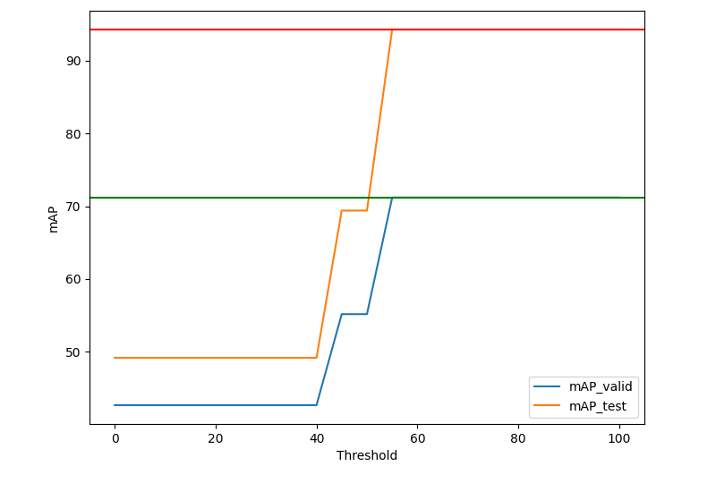

(a) mAP curves

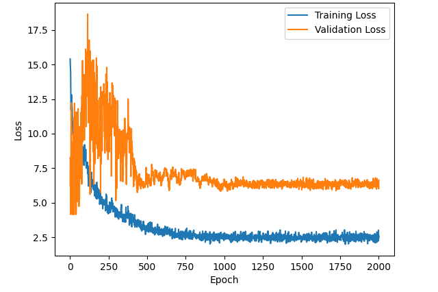

(b) Loss curves

Figure 1: Train, Validation and Test Descriptors hyperparameter set 22

**Descriptors - 26**

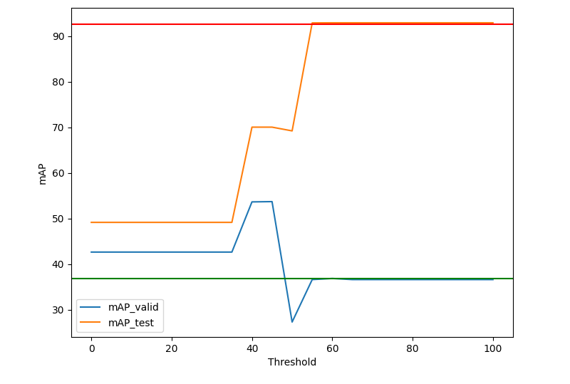

(a) mAP curves

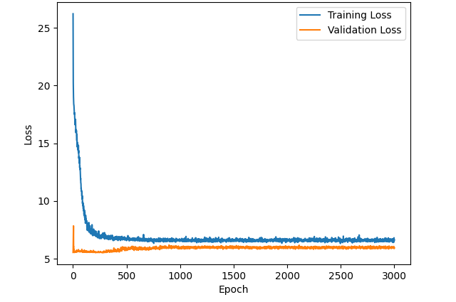

(b) Loss curves

Figure 2: Train, Validation and Test Descriptors hyperparameter set 26

**Hold-out**

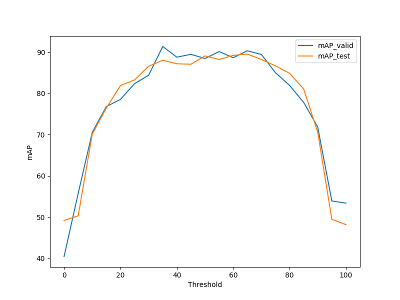

(a) mAP curves

[figure not shown]

Figure 3: Train (valid-holdout), and Test Descriptors - best of the 26 hyperparameter set

**Experiment 2 Results**

In Experiment 2, we obtained the train and test decriptors of the best validation accuracy from the 26 sets of hyperparameters that achieved statistically significant COSFIRE filters with the validation set during the classification study. Subsequently, the training dataset was divided into training and validation subsets using a hold-out methodology at a ratio of 9:1, which was empirically found to be an optimal hold-out ratio.

We then conducted 10 runs for each MLP hyperparameter set during the grid search.

**Tip**

Each row represents a unique combination of MLP hyperparameters, and every column represents the results yielded by each of the 10 random runs on the training dataset. The numbers 2, 12, 22,…, 92 represents the seed values used for reproducibility.

**Important**

This is the approach that was discussed in the last meeting. I have included it in this presentation since I already had some preliminary results and are useful for comparisons.

NB: The code used is [GitHub](https://GitHub.com/stevenndungu/deep_hashing/blob/main/validation_script_grid_search_17052024.py)

#### Validation Data mAP Results Preview:

Here is the [Google Sheet Version](https://docs.google.com/spreadsheets/d/1WC40gNFsJhQhw-EFt95JxJcUxgIWqykV_nN-a_jXGT0/edit?usp=sharing) of the data

|  | input_size | output_size | learning_rate | batch_size | alpha | margin | mAP_valid_seed_2 | mAP_valid_seed_12 | mAP_valid_seed_22 | mAP_valid_seed_32 | mAP_valid_seed_42 | mAP_valid_seed_52 | mAP_valid_seed_62 | mAP_valid_seed_72 | mAP_valid_seed_82 | mAP_valid_seed_92 |
| --- | --- | --- | --- | --- | --- | --- | --- | --- | --- | --- | --- | --- | --- | --- | --- | --- |
| 0 | 400 | 36 | 0.100 | 16 | 0.00001 | 24 | 74.42 | 80.31 | 76.24 | 74.69 | 78.28 | 68.04 | 79.16 | 79.41 | 78.31 | 81.87 |
| 1 | 400 | 36 | 0.100 | 32 | 0.00001 | 24 | 78.02 | 87.22 | 81.23 | 75.18 | 83.93 | 83.29 | 84.26 | 80.83 | 81.25 | 87.30 |
| 2 | 400 | 36 | 0.100 | 64 | 0.00001 | 24 | 80.41 | 82.51 | 79.58 | 75.66 | 83.63 | 80.96 | 82.55 | 78.75 | 83.59 | 85.58 |
| 3 | 400 | 36 | 0.100 | 16 | 0.00001 | 36 | 79.84 | 82.39 | 73.63 | 78.26 | 87.54 | 77.65 | 79.23 | 79.97 | 79.11 | 83.58 |
| 4 | 400 | 36 | 0.100 | 32 | 0.00001 | 36 | 83.82 | 83.40 | 82.09 | 76.75 | 86.39 | 82.32 | 84.16 | 81.05 | 80.58 | 86.48 |
| 5 | 400 | 36 | 0.100 | 64 | 0.00001 | 36 | 82.62 | 81.70 | 79.32 | 80.93 | 86.48 | 82.51 | 82.51 | 80.22 | 80.99 | 82.46 |
| 6 | 400 | 36 | 0.100 | 16 | 0.00001 | 48 | 64.80 | 66.25 | 62.72 | 62.10 | 62.88 | 66.30 | 62.77 | 65.57 | 67.73 | 62.56 |
| 7 | 400 | 36 | 0.100 | 32 | 0.00001 | 48 | 65.54 | 69.79 | 62.53 | 62.77 | 64.64 | 72.14 | 64.56 | 71.65 | 68.33 | 62.79 |
| 8 | 400 | 36 | 0.100 | 64 | 0.00001 | 48 | 65.95 | 72.39 | 65.62 | 62.21 | 68.46 | 72.11 | 66.48 | 70.63 | 70.99 | 84.27 |
| 9 | 400 | 36 | 0.100 | 16 | 0.00010 | 24 | 77.49 | 80.42 | 77.20 | 74.17 | 78.25 | 79.77 | 77.84 | 75.80 | 79.25 | 82.92 |
| 10 | 400 | 36 | 0.100 | 32 | 0.00010 | 24 | 80.72 | 82.24 | 82.01 | 80.48 | 87.89 | 85.14 | 83.98 | 81.90 | 84.04 | 84.53 |
| 11 | 400 | 36 | 0.100 | 64 | 0.00010 | 24 | 85.35 | 80.86 | 77.88 | 80.41 | 86.71 | 82.59 | 85.52 | 79.23 | 80.18 | 82.91 |
| 12 | 400 | 36 | 0.100 | 16 | 0.00010 | 36 | 75.54 | 83.24 | 75.43 | 78.85 | 85.48 | 79.47 | 81.03 | 80.45 | 79.97 | 81.55 |
| 13 | 400 | 36 | 0.100 | 32 | 0.00010 | 36 | 81.07 | 83.43 | 78.94 | 80.10 | 88.56 | 83.39 | 83.65 | 80.62 | 85.16 | 86.21 |
| 14 | 400 | 36 | 0.100 | 64 | 0.00010 | 36 | 83.32 | 79.94 | 80.03 | 77.01 | 84.15 | 80.55 | 79.35 | 83.02 | 85.03 | 83.66 |
| 15 | 400 | 36 | 0.100 | 16 | 0.00010 | 48 | 63.65 | 65.96 | 62.55 | 63.17 | 64.44 | 68.11 | 63.75 | 66.80 | 68.06 | 61.60 |
| 16 | 400 | 36 | 0.100 | 32 | 0.00010 | 48 | 65.04 | 70.17 | 64.52 | 62.60 | 65.89 | 69.85 | 63.08 | 67.16 | 67.99 | 61.82 |
| 17 | 400 | 36 | 0.100 | 64 | 0.00010 | 48 | 68.51 | 67.83 | 64.58 | 66.98 | 70.64 | 66.31 | 66.23 | 70.31 | 72.13 | 61.77 |
| 18 | 400 | 36 | 0.100 | 16 | 0.00100 | 24 | 82.58 | 77.18 | 78.83 | 77.88 | 79.86 | 75.14 | 79.75 | 78.37 | 77.26 | 79.27 |
| 19 | 400 | 36 | 0.100 | 32 | 0.00100 | 24 | 83.51 | 83.49 | 78.46 | 82.09 | 84.43 | 84.27 | 83.31 | 81.00 | 83.36 | 87.21 |
| 20 | 400 | 36 | 0.100 | 64 | 0.00100 | 24 | 81.66 | 82.20 | 79.72 | 79.43 | 86.70 | 83.52 | 80.33 | 80.41 | 85.76 | 83.28 |
| 21 | 400 | 36 | 0.100 | 16 | 0.00100 | 36 | 77.01 | 80.14 | 79.44 | 77.00 | 87.25 | 81.73 | 81.93 | 79.09 | 79.42 | 81.94 |
| 22 | 400 | 36 | 0.100 | 32 | 0.00100 | 36 | 82.74 | 79.21 | 80.11 | 79.32 | 83.23 | 80.36 | 83.71 | 83.26 | 81.22 | 83.80 |
| 23 | 400 | 36 | 0.100 | 64 | 0.00100 | 36 | 83.37 | 81.61 | 80.79 | 80.94 | 83.71 | 82.76 | 83.04 | 77.50 | 81.24 | 86.51 |
| 24 | 400 | 36 | 0.100 | 16 | 0.00100 | 48 | 64.02 | 66.58 | 62.90 | 61.83 | 67.94 | 68.86 | 65.14 | 66.85 | 69.48 | 59.87 |
| 25 | 400 | 36 | 0.100 | 32 | 0.00100 | 48 | 71.46 | 66.74 | 63.90 | 67.30 | 65.03 | 68.80 | 66.93 | 71.11 | 69.09 | 63.42 |
| 26 | 400 | 36 | 0.100 | 64 | 0.00100 | 48 | 67.94 | 69.60 | 68.25 | 68.34 | 69.74 | 72.96 | 66.48 | 70.24 | 69.45 | 68.56 |
| 27 | 400 | 36 | 0.010 | 16 | 0.00001 | 24 | 87.51 | 79.97 | 78.80 | 80.69 | 85.56 | 85.65 | 83.34 | 82.22 | 80.90 | 86.03 |
| 28 | 400 | 36 | 0.010 | 32 | 0.00001 | 24 | 85.48 | 84.53 | 82.22 | 80.11 | 87.70 | 83.77 | 83.87 | 82.37 | 83.40 | 85.30 |
| 29 | 400 | 36 | 0.010 | 64 | 0.00001 | 24 | 85.90 | 86.57 | 82.09 | 82.08 | 85.80 | 84.53 | 84.30 | 82.34 | 83.64 | 85.28 |

[output cut: 51 more lines]

#### Test Data mAP Results Preview:

Here is the [Google Sheet Version](https://docs.google.com/spreadsheets/d/1-AdJzAh8rlWpNatnJaxAs9fAZWmYss-miFYamn219e4/edit?usp=sharing) of the data

|  | input_size | output_size | learning_rate | batch_size | alpha | margin | mAP_test_seed_2 | mAP_test_seed_12 | mAP_test_seed_22 | mAP_test_seed_32 | mAP_test_seed_42 | mAP_test_seed_52 | mAP_test_seed_62 | mAP_test_seed_72 | mAP_test_seed_82 | mAP_test_seed_92 |
| --- | --- | --- | --- | --- | --- | --- | --- | --- | --- | --- | --- | --- | --- | --- | --- | --- |
| 0 | 400 | 36 | 0.100 | 16 | 0.00001 | 24 | 83.71 | 90.62 | 89.98 | 84.75 | 85.35 | 71.09 | 89.56 | 86.83 | 89.43 | 87.38 |
| 1 | 400 | 36 | 0.100 | 32 | 0.00001 | 24 | 89.61 | 90.53 | 89.28 | 86.73 | 90.70 | 87.65 | 91.70 | 87.07 | 88.73 | 94.04 |
| 2 | 400 | 36 | 0.100 | 64 | 0.00001 | 24 | 91.94 | 88.98 | 90.86 | 89.22 | 91.05 | 87.93 | 90.91 | 90.31 | 90.73 | 91.19 |
| 3 | 400 | 36 | 0.100 | 16 | 0.00001 | 36 | 90.13 | 90.33 | 86.32 | 89.02 | 90.63 | 88.25 | 90.33 | 87.03 | 89.27 | 90.31 |
| 4 | 400 | 36 | 0.100 | 32 | 0.00001 | 36 | 90.76 | 92.16 | 90.04 | 89.18 | 89.58 | 88.32 | 89.40 | 91.92 | 87.43 | 91.69 |
| 5 | 400 | 36 | 0.100 | 64 | 0.00001 | 36 | 89.44 | 90.33 | 90.91 | 92.41 | 89.72 | 90.50 | 90.22 | 91.34 | 88.09 | 90.88 |
| 6 | 400 | 36 | 0.100 | 16 | 0.00001 | 48 | 76.39 | 71.66 | 83.38 | 80.46 | 75.97 | 74.15 | 78.66 | 73.26 | 74.78 | 72.05 |
| 7 | 400 | 36 | 0.100 | 32 | 0.00001 | 48 | 67.15 | 87.59 | 83.16 | 85.19 | 68.21 | 90.24 | 67.81 | 87.03 | 85.73 | 87.22 |
| 8 | 400 | 36 | 0.100 | 64 | 0.00001 | 48 | 78.86 | 73.27 | 86.71 | 72.35 | 74.89 | 88.86 | 87.93 | 91.29 | 77.40 | 89.22 |
| 9 | 400 | 36 | 0.100 | 16 | 0.00010 | 24 | 86.18 | 87.54 | 88.51 | 85.89 | 85.01 | 84.20 | 85.43 | 87.56 | 86.09 | 89.35 |
| 10 | 400 | 36 | 0.100 | 32 | 0.00010 | 24 | 88.81 | 90.23 | 90.36 | 89.05 | 91.15 | 88.88 | 87.64 | 89.26 | 91.88 | 91.42 |
| 11 | 400 | 36 | 0.100 | 64 | 0.00010 | 24 | 90.32 | 91.92 | 90.85 | 90.83 | 91.87 | 89.02 | 92.16 | 90.55 | 90.21 | 91.45 |
| 12 | 400 | 36 | 0.100 | 16 | 0.00010 | 36 | 87.52 | 88.67 | 89.14 | 91.63 | 89.13 | 85.87 | 86.95 | 90.13 | 86.67 | 88.34 |
| 13 | 400 | 36 | 0.100 | 32 | 0.00010 | 36 | 91.42 | 91.01 | 88.23 | 89.13 | 91.26 | 90.36 | 88.56 | 89.05 | 92.19 | 90.89 |
| 14 | 400 | 36 | 0.100 | 64 | 0.00010 | 36 | 90.91 | 90.81 | 92.47 | 92.01 | 90.48 | 93.09 | 88.76 | 90.59 | 88.20 | 91.48 |
| 15 | 400 | 36 | 0.100 | 16 | 0.00010 | 48 | 68.31 | 74.70 | 80.30 | 75.66 | 76.71 | 83.07 | 74.06 | 74.18 | 71.50 | 71.32 |
| 16 | 400 | 36 | 0.100 | 32 | 0.00010 | 48 | 79.90 | 88.78 | 83.81 | 77.31 | 70.71 | 76.20 | 75.29 | 85.66 | 86.44 | 72.17 |
| 17 | 400 | 36 | 0.100 | 64 | 0.00010 | 48 | 74.10 | 87.42 | 73.43 | 88.89 | 88.33 | 73.44 | 74.95 | 87.98 | 86.98 | 79.44 |
| 18 | 400 | 36 | 0.100 | 16 | 0.00100 | 24 | 86.58 | 86.86 | 89.97 | 87.84 | 86.63 | 85.55 | 89.14 | 82.66 | 86.28 | 89.85 |
| 19 | 400 | 36 | 0.100 | 32 | 0.00100 | 24 | 91.12 | 89.89 | 91.53 | 90.61 | 92.71 | 90.89 | 89.64 | 90.59 | 91.75 | 90.91 |
| 20 | 400 | 36 | 0.100 | 64 | 0.00100 | 24 | 91.97 | 93.09 | 90.46 | 89.83 | 91.20 | 88.87 | 87.91 | 91.57 | 90.85 | 92.60 |
| 21 | 400 | 36 | 0.100 | 16 | 0.00100 | 36 | 89.01 | 90.13 | 88.46 | 91.56 | 88.75 | 84.52 | 89.93 | 90.07 | 86.81 | 90.52 |
| 22 | 400 | 36 | 0.100 | 32 | 0.00100 | 36 | 90.74 | 88.88 | 89.45 | 91.32 | 89.60 | 89.19 | 90.33 | 90.86 | 90.82 | 90.67 |
| 23 | 400 | 36 | 0.100 | 64 | 0.00100 | 36 | 92.24 | 90.95 | 90.58 | 90.80 | 90.40 | 89.08 | 90.29 | 90.47 | 91.82 | 90.62 |
| 24 | 400 | 36 | 0.100 | 16 | 0.00100 | 48 | 82.20 | 82.49 | 67.80 | 73.41 | 73.90 | 69.67 | 73.15 | 73.75 | 75.01 | 76.79 |
| 25 | 400 | 36 | 0.100 | 32 | 0.00100 | 48 | 89.92 | 74.17 | 86.98 | 84.91 | 76.08 | 87.76 | 87.86 | 70.07 | 74.20 | 88.52 |
| 26 | 400 | 36 | 0.100 | 64 | 0.00100 | 48 | 88.80 | 90.36 | 90.51 | 90.38 | 71.16 | 91.07 | 77.87 | 93.17 | 84.93 | 75.78 |
| 27 | 400 | 36 | 0.010 | 16 | 0.00001 | 24 | 90.08 | 89.22 | 81.74 | 90.45 | 90.33 | 84.82 | 88.40 | 88.22 | 87.45 | 88.17 |
| 28 | 400 | 36 | 0.010 | 32 | 0.00001 | 24 | 88.14 | 92.13 | 87.33 | 87.93 | 87.45 | 87.41 | 90.69 | 87.10 | 90.74 | 90.68 |
| 29 | 400 | 36 | 0.010 | 64 | 0.00001 | 24 | 90.28 | 88.51 | 90.37 | 90.43 | 90.14 | 90.17 | 92.16 | 90.93 | 90.19 | 87.39 |

[output cut: 51 more lines]

The global maximum row:

```python
################
df_base_valid_st = df_base_valid[list(df_base_valid.columns[df_base_valid.columns.str.startswith('mAP_valid')])]

# Apply the function row-wise
df_base_valid_st['max_map'] = df_base_valid_st.apply(find_max, axis=1)

df_base_valid['max_map'] = df_base_valid.apply(find_max, axis=1)
df_base_valid_st.sort_values(by='max_map', ascending=False, inplace=True)

#maximum Value
df_base_valid_st['max_map'].max()


# extract max value row.
max_index = df_base_valid_st['max_map'].idxmax()
max_row = df_base_valid_st.loc[max_index]
#print(max_row)
```

|  | mAP_valid_seed_2 | mAP_valid_seed_12 | mAP_valid_seed_22 | mAP_valid_seed_32 | mAP_valid_seed_42 | mAP_valid_seed_52 | mAP_valid_seed_62 | mAP_valid_seed_72 | mAP_valid_seed_82 | mAP_valid_seed_92 | max_map |
| --- | --- | --- | --- | --- | --- | --- | --- | --- | --- | --- | --- |
| 72 | 85.14 | 82.83 | 79.8 | 81.15 | 89.5 | 85.61 | 81.19 | 83.65 | 83.18 | 85.66 | 89.5 |

#### Statstical Significance:

```python
pvalues = []

for _,index in enumerate(df_base_valid_st.index):
  _, p_value = stats.ttest_ind(max_row[:-1], df_base_valid_st.loc[index][:-1], alternative='greater')
  pvalues.append((p_value>=0.05)*1)


df_base_valid_st['sig'] = pvalues
df_base_valid_st1 = df_base_valid_st.query('sig == 1')


max_indexx = df_base_valid_st1.iloc[:, :-3].mean().idxmax()

#print(sum(pvalues),max_indexx)
```

[figure not shown]

**Model performance on valid data**

Average & Std Deviation of the Significant rows:

|  | mean | std |
| --- | --- | --- |
| max_map | 87.265128 | 0.890230 |
| mAP_valid_seed_42 | 86.309231 | 1.398933 |
| mAP_valid_seed_92 | 85.119744 | 3.609128 |
| mAP_valid_seed_2 | 84.612821 | 2.132447 |
| mAP_valid_seed_52 | 83.958718 | 1.578932 |
| mAP_valid_seed_12 | 83.543846 | 3.354295 |
| mAP_valid_seed_62 | 83.493846 | 1.496843 |
| mAP_valid_seed_82 | 82.320256 | 1.970125 |
| mAP_valid_seed_72 | 81.569744 | 1.722606 |
| mAP_valid_seed_32 | 80.567692 | 1.856615 |
| mAP_valid_seed_22 | 80.453333 | 1.371563 |
| sig | 1.000000 | 0.000000 |

**Model performance on Test data**

We then pply the hyperparameters to the test set and average the results.

```python
####################################################
# Use the hyperparameters to the test data.
####################################################
optimal_params = df_base_valid.iloc[df_base_valid_st1.index].iloc[:, :6].reset_index()
optimal_params.drop(['index'], axis=1, inplace = True)

#rotation invariance test data with optimal parameters
test_data_1 = pd.merge(optimal_params, df_base_test, how='left')
test_data_1_sub = test_data_1[list(test_data_1.columns[test_data_1.columns.str.startswith('mAP_test_seed')])]
test_data_1['max_map'] = test_data_1_sub.apply(find_max, axis=1)
test_data_1['average_map'] = test_data_1_sub.apply(np.mean, axis=1)

test_data_1.sort_values(by=['average_map'], ascending= False,inplace=True)

res_1 = test_data_1.describe().iloc[1:3][list(test_data_1.columns[test_data_1.columns.str.startswith('mAP_test_seed')]) + ['average_map']]
```

|  | mean | std |
| --- | --- | --- |
| mAP_test_seed_32 | 89.817692 | 1.471212 |
| mAP_test_seed_92 | 89.445385 | 3.046971 |
| mAP_test_seed_62 | 89.300513 | 1.459410 |
| mAP_test_seed_2 | 89.256410 | 1.501278 |
| mAP_test_seed_82 | 89.129744 | 1.908327 |
| mAP_test_seed_72 | 89.118718 | 1.745533 |
| average_map | 89.102718 | 1.220604 |
| mAP_test_seed_42 | 89.020769 | 1.824995 |
| mAP_test_seed_22 | 88.917179 | 2.032986 |
| mAP_test_seed_12 | 88.614615 | 3.545667 |
| mAP_test_seed_52 | 88.406154 | 1.787269 |